# Starbucks

## Portfolio Exercise Starbucks

#### Background Information

The dataset, provided by Starbucks, consists of about 120,000 data points split in 2:1 ratio among training and test files. Each data point includes one column indicating whether or not an individual was sent a promotion for a specific product, and one column indicating whether or not that individual eventually purchased that product. Each individual also had seven additional features associated with them.

#### Optimization Strategy

Your task is to use the training data to understand what patterns in V1-V7 to indicate that a promotion should be provided to a user. Specifically, your goal is to maximize the following metrics:

- **Incremental Response Rate (IRR)**

Ratio of the number of purchasers in the promotion group to the total number of customers in the purchasers group minus the ratio of the number of purchasers in the non-promotional group to the total number of customers in the non-promotional group.

$$ IRR = \frac{purch_{treat}}{cust_{treat}} - \frac{purch_{ctrl}}{cust_{ctrl}} $$

- **Net Incremental Revenue (NIR)**

The total number of purchasers that received the promotion times 10 minus the number of promotions given times 0.15 minus the number of purchasers who were not given the promotion times 10.

$$ NIR = (10\cdot purch_{treat} - 0.15 \cdot cust_{treat}) - 10 \cdot purch_{ctrl}$$

For a full description of what starbucks provides to candidates see the [instructions available here](https://drive.google.com/open?id=18klca9Sef1Rs6q8DW4l7o349r8B70qXM).

Below you can find the training data provided. Explore the data and different optimization strategies.

#### How To Test Your Strategy?

When you feel like you have an optimization strategy, complete the **promotion_strategy** function to pass to the **test_results** function.  
From past data, we know there are four possible outomes:

Table of actual promotion vs. predicted promotion customers.

|  | Actual |  |  |
| --- | --- | --- | --- |
| **Predicted** | Yes | No |  |
| Yes | **I** | **II** |  |
| No | **III** | **IV** |  |

The metrics are only being compared for the individual's we predict should obtain the promotion - that is quadrants I and II here. Since the first set of individuals that receive the promotion (in the training set) receive it randomly, we can expect that quadrants I and II will have approximately equal participants.

Comparing quadrant I to II then gives an idea of how well your promotion strategy will work in the future.

Get started by reading in the data below. See how each variable or combination of variables along with a promotion influences the chance of purchasing. When you feel like you have a strategy for who should receive a promotion, test your strategy against the test dataset used in the final test_results function.

```python
# load in packages
from itertools import combinations

import numpy as np
import pandas as pd
import scipy as sp
import sklearn as sk

import matplotlib.pyplot as plt
import seaborn as sb
from imblearn.over_sampling import SMOTE

from sklearn.neighbors import KNeighborsClassifier
from sklearn.svm import SVC
from sklearn.gaussian_process import GaussianProcessClassifier
from sklearn.gaussian_process.kernels import RBF, Kernel
from sklearn.tree import DecisionTreeClassifier
from sklearn.ensemble import RandomForestClassifier, AdaBoostClassifier
from sklearn.naive_bayes import GaussianNB
from sklearn.discriminant_analysis import QuadraticDiscriminantAnalysis
from sklearn.model_selection import train_test_split, GridSearchCV
from sklearn.preprocessing import OneHotEncoder
from sklearn.metrics import f1_score, accuracy_score,confusion_matrix
from sklearn.pipeline import Pipeline
from sklearn.preprocessing import StandardScaler
import pickle

%matplotlib inline

# load in the data
train_data = pd.read_csv('data/training.csv')
train_data.head()
```

|  | ID | Promotion | purchase | V1 | V2 | V3 | V4 | V5 | V6 | V7 |
| --- | --- | --- | --- | --- | --- | --- | --- | --- | --- | --- |
| 0 | 1 | No | 0 | 2 | 30.443518 | -1.165083 | 1 | 1 | 3 | 2 |
| 1 | 3 | No | 0 | 3 | 32.159350 | -0.645617 | 2 | 3 | 2 | 2 |
| 2 | 4 | No | 0 | 2 | 30.431659 | 0.133583 | 1 | 1 | 4 | 2 |
| 3 | 5 | No | 0 | 0 | 26.588914 | -0.212728 | 2 | 1 | 4 | 2 |
| 4 | 8 | Yes | 0 | 3 | 28.044332 | -0.385883 | 1 | 1 | 2 | 2 |

```python
train_data.describe()
```

|  | ID | purchase | V1 | V2 | V3 | V4 | V5 | V6 | V7 |
| --- | --- | --- | --- | --- | --- | --- | --- | --- | --- |
| count | 84534.000000 | 84534.000000 | 84534.000000 | 84534.000000 | 84534.000000 | 84534.000000 | 84534.000000 | 84534.000000 | 84534.000000 |
| mean | 62970.972413 | 0.012303 | 1.500662 | 29.973600 | 0.000190 | 1.679608 | 2.327643 | 2.502898 | 1.701694 |
| std | 36418.440539 | 0.110234 | 0.868234 | 5.010626 | 1.000485 | 0.466630 | 0.841167 | 1.117349 | 0.457517 |
| min | 1.000000 | 0.000000 | 0.000000 | 7.104007 | -1.684550 | 1.000000 | 1.000000 | 1.000000 | 1.000000 |
| 25% | 31467.250000 | 0.000000 | 1.000000 | 26.591501 | -0.905350 | 1.000000 | 2.000000 | 2.000000 | 1.000000 |
| 50% | 62827.500000 | 0.000000 | 2.000000 | 29.979744 | -0.039572 | 2.000000 | 2.000000 | 3.000000 | 2.000000 |
| 75% | 94438.750000 | 0.000000 | 2.000000 | 33.344593 | 0.826206 | 2.000000 | 3.000000 | 4.000000 | 2.000000 |
| max | 126184.000000 | 1.000000 | 3.000000 | 50.375913 | 1.691984 | 2.000000 | 4.000000 | 4.000000 | 2.000000 |

```python
train_data.info()
```

```
<class 'pandas.core.frame.DataFrame'>
RangeIndex: 84534 entries, 0 to 84533
Data columns (total 10 columns):
 #   Column     Non-Null Count  Dtype
---  ------     --------------  -----
 0   ID         84534 non-null  int64
 1   Promotion  84534 non-null  object
 2   purchase   84534 non-null  int64
 3   V1         84534 non-null  int64
 4   V2         84534 non-null  float64
 5   V3         84534 non-null  float64
 6   V4         84534 non-null  int64
 7   V5         84534 non-null  int64
 8   V6         84534 non-null  int64
 9   V7         84534 non-null  int64
dtypes: float64(2), int64(7), object(1)
memory usage: 6.4+ MB
```

## 1. Analyse the experiment results and identify the treatment effect

```python
def create_annotation(ax):
    '''create annotations on the bar

    args:
        ax: matplotlib axes
    '''
    for p in ax.patches:
        x=p.get_bbox().get_points()[:,0]
        y=p.get_bbox().get_points()[1,1]
        ax.annotate('{:.3f}'.format(p.get_height()),(x.mean(),y),ha='center',va='bottom')
```

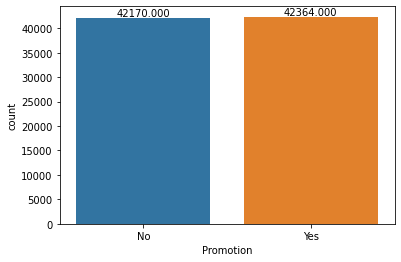

```python
#number of people receiving the promotions and not receiving the promotion
ax1=sb.countplot(data=train_data, x='Promotion')

create_annotation(ax1)
```

### Sanity check: the number of people receiving promotion vs not receiving promotions are the same

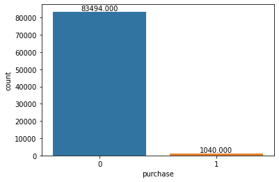

```python
#number of people making purchase and not making purchase
ax2=sb.countplot(data=train_data, x='purchase')

create_annotation(ax2)
```

### The dataset is highly unbalanced as there is much fewer people who make purchase.

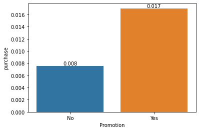

```python
#purchase rate in the promotion group and non-promotion group
ax3=sb.barplot(data=train_data,x='Promotion',y='purchase',ci=None)

create_annotation(ax3)
```

```python
def calculate_irr(df):
    '''calculate the incremental response rate from the dataset

    args:
        df: pandas dataframe
    '''
    df_purchase_rate=df.groupby(by=['Promotion'])['purchase'].mean()
    return df_purchase_rate['Yes']-df_purchase_rate['No']
```

```python
print('the incremental response rate is: {:.3f}'.format(calculate_irr(train_data)))
```

```
the incremental response rate is: 0.009
```

```python
def calculate_nir(df):
    '''calculate the net incremental revenue from the dataset

    args:
        df: pandas dataframe
    '''
    num_tre_pur=df[(df['Promotion']=='Yes') & (df['purchase']==1)].shape[0]
    num_tre=df[df['Promotion']=='Yes'].shape[0]
    num_con_pur=df[(df['Promotion']=='No') & (df['purchase']==1)].shape[0]

    nir=10*num_tre_pur-0.15*num_tre-10*num_con_pur

    return nir
```

```python
print('the net incremental revenue is: {:.3f}'.format(calculate_nir(train_data)))
```

```
the net incremental revenue is: -2334.600
```

# 2. Determine if the IRR result is statistically significant

**H0**: ${P}_{tre}-{P}_{ctl} \leq 0$

**H1**: ${P}_{tre}-{P}_{ctl} \gt 0$

```python
purchase_rate_pool=train_data['purchase'].mean()

num_tre=train_data[train_data['Promotion']=='Yes'].shape[0]
num_ctl=train_data[train_data['Promotion']=='No'].shape[0]

pool_se=np.sqrt((1-purchase_rate_pool)*purchase_rate_pool*(1/num_tre+1/num_ctl))
irr=calculate_irr(train_data)#irr is the purchase rate in promotion group minus non-promotion group

if irr/pool_se>sp.stats.norm.ppf(0.95):
    print('the null hypothesis is rejected with the significance level of 0.05')
else:
    print('the null hypothesis is accepted with the significance level of 0.05')
```

```
the null hypothesis is rejected with the significance level of 0.05
```

### Interpretation

Based on the results above, we can say that people in promotion group are more likely to purchase than people in non-promotional group. Therefore, the promotion is beneficial in terms of people's reponse rate.

# 3. Determine if the IRR result is practically significant

Assume that there are the same number of people in both the promotion and non-promotion group, then in order for the net incremental revenue(nir) to be positive or the irr result to be practically significant, the incremental response rate should be over 0.015 according to the nir equation above

**H0**: ${P}_{tre}-{P}_{ctl} \leq 0.015$

**H1**: ${P}_{tre}-{P}_{ctl} \gt 0.015$

```python
rr_tre = train_data[train_data['Promotion']=='Yes']['purchase'].mean()
rr_clr = train_data[train_data['Promotion']=='No']['purchase'].mean()

se=np.sqrt((1-rr_tre)*rr_tre/num_tre+(1-rr_clr)*rr_clr/num_ctl)

t_score=(irr-0.015)/se
p=1-sp.stats.norm.cdf(t_score)

if p>0.05:
    print('the null hypothesis is accepted')
else:
    print('the null hypothesis is rejected')
```

```
the null hypothesis is accepted
```

### Interpretation:

Under the assumption that there are same number of people in both the promotion and non-promotion group, the IRR result is not practically significant and net incremental revenue is less than 0.

Promotion also need money, and we want to only send promotion to people who are most likely to purchase and avoid people who seems have no interest in the promotions.

**That brings to mind a classification problem, and we aim to establish a model to predict whether a user might purchase in order avoid people who may not be impacted, and increase the net incremental revenue.**

# 3. Establish a predictive model

The dataset is highly **imbalanced**, and that might influence classifier performance such as resulting in the classifier ignoring the minority class. Therefore, we would like to **downsample the majority class** so the majority and minority have a ratio of 2:1.

```python
def downsample_majority(X_train,y_train,n):
    '''downsample the dataset
    '''
    # We downsample our dominant class in our training set
    i_class0 = np.where(y_train == 0)[0]
    i_class1 = np.where(y_train == 1)[0]

    # Number of observations in each class
    n_class0 = len(i_class0)
    n_class1 = len(i_class1)

    # For every observation of class 0, randomly sample from class 1 without replacement
    i_class0_downsampled = np.random.choice(i_class0, size=n_class1*2, replace=False)

    # Create new indices based on the downsampled class 0
    indices = np.concatenate((i_class0_downsampled, i_class1))
    np.random.shuffle(indices) # we shuffle to avoid order in our dataset

    # We subset our X_train and y_train datasets, we now have a ratio of 2:1 for class 0 vs 1
    X_train = X_train.iloc[indices]
    y_train = y_train.iloc[indices]

    return X_train,y_train

def optimize_classifier(X,y):
    '''tuning the hyperparameters of linear SVC

    args:
        X, y: ndarray. Training dataset

    returns:
        classifier: a sklearn classifier with fine tuned hyperparameters
    '''

    dt=DecisionTreeClassifier()
    gs=GridSearchCV(dt,param_grid={'max_depth':[3,4,5],'min_samples_split':[2,4,6],'min_samples_leaf':[1,3,5],'max_leaf_nodes':[5,10,15]},scoring='f1')

    gs.fit(X,y)

    return gs.best_estimator_
```

```python
X=train_data.iloc[:,3:]
y=train_data['purchase']


X_train, X_test, y_train, y_test = train_test_split(X, y, test_size=0.2, random_state=42)
X_train,y_train=downsample_majority(X_train,y_train,2)

classifier = optimize_classifier(X_train,y_train)
classifier.fit(X_train,y_train)
```

```
DecisionTreeClassifier(max_depth=5, max_leaf_nodes=15, min_samples_leaf=5)
```

```python
#features=['V1','V4','V5']
def promotion_strategy(df):
    '''
    INPUT
    df - a dataframe with *only* the columns V1 - V7 (same as train_data)

    OUTPUT
    promotion_df - np.array with the values
                   'Yes' or 'No' related to whether or not an
                   individual should recieve a promotion
                   should be the length of df.shape[0]

    Ex:
    INPUT: df

    V1	V2	  V3	V4	V5	V6	V7
    2	30	-1.1	1	1	3	2
    3	32	-0.6	2	3	2	2
    2	30	0.13	1	1	4	2

    OUTPUT: promotion

    array(['Yes', 'Yes', 'No'])
    indicating the first two users would recieve the promotion and
    the last should not.
    '''
    y_score=classifier.predict_proba(df)[:,1]
    promotion=np.zeros((len(y_score),1))
    promotion[y_score>0.3670]=1

    my_dict={1:'Yes',0:'No'}
    promotion=np.vectorize(my_dict.get)(promotion)
    return promotion
```

```python
def score(df, promo_pred_col = 'Promotion'):
    n_treat       = df.loc[df[promo_pred_col] == 'Yes',:].shape[0]
    n_control     = df.loc[df[promo_pred_col] == 'No',:].shape[0]
    n_treat_purch = df.loc[df[promo_pred_col] == 'Yes', 'purchase'].sum()
    n_ctrl_purch  = df.loc[df[promo_pred_col] == 'No', 'purchase'].sum()
    irr = n_treat_purch / n_treat - n_ctrl_purch / n_control
    nir = 10 * n_treat_purch - 0.15 * n_treat - 10 * n_ctrl_purch
    return (irr, nir)
```

```python
def test_results(promotion_strategy):
    test_data = pd.read_csv('Test.csv')
    df = test_data[['V1', 'V2', 'V3', 'V4', 'V5', 'V6', 'V7']]
    promos = promotion_strategy(df)
    score_df = test_data.iloc[np.where(promos.flatten() == 'Yes')[0]]
    irr, nir = score(score_df)
    print("Nice job!  See how well your strategy worked on our test data below!")
    print()
    print('Your irr with this strategy is {:0.2f}.'.format(irr))
    print()
    print('Your nir with this strategy is {:0.2f}.'.format(nir))
    return irr, nir
```

```python
# This will test your results, and provide you back some information
# on your how well your promotion_strategy will work in practice
test_results(promotion_strategy)
```

```
Nice job!  See how well your strategy worked on our test data below!

Your irr with this strategy is 0.02.

Your nir with this strategy is 316.25.
```

```
(0.01911685748650762, 316.25)
```